# Lab-10-Replication

Branson Fox

(March 30, 2019)

## Introduction

This notebook replicates the results for lab-10 - Density of Public Schools in Missouri.

## Dependencies

This notebook requires the following packages to manipulate our data and create maps.

```r
# tidyverse packages
library(dplyr)   # methods for data manipulation
library(ggplot2) # making plots/maps

# other packages
library(sf)      # tools for spatial
library(here)    # file path management
library(mapview) # interactive exploratory map
library(viridis) # accessible color palettes
```

## Load Data

This notebook requires the K-12 Schools data and the County Population data. Note the `crs = 4269` specified for schools. This is because the original shapefile did not contain a coordinate system. Usually this won’t be the case.

```r
schools <- st_read(here("data","MO_EDU_PublicK12","MO_EDU_PublicK12.shp"),stringsAsFactors = FALSE, crs = 4269)
counties <- st_read(here("data","MO_DEMOS_CountyPop","MO_DEMOS_CountyPop.shp"), stringsAsFactors = FALSE)
```

## Part 1: Data Preparation

### Question 1

We’ll begin by checking that our data are in the same coordinate system.

```r
st_crs(schools)
```

```
Coordinate Reference System:
  EPSG: 4269
  proj4string: "+proj=longlat +ellps=GRS80 +towgs84=0,0,0,0,0,0,0 +no_defs"
```

```r
st_crs(counties)
```

```
Coordinate Reference System:
  EPSG: 4269
  proj4string: "+proj=longlat +datum=NAD83 +no_defs"
```

Our data are in the same coordinate system, but they need to be projected to something appropriate for statewide Missouri data. We’ll use UTM 15N, epsg 26915, because it captures most of the extent of Missouri.

```r
schools <- st_transform(schools, crs = 26915)
counties <- st_transform(counties, crs = 26915)
```

Next, we need to create a spatial join that identifies the county each school is located in. We pipe into a select function in order to remove the extra county variables.

```r
schools_county <- st_intersection(schools, counties) %>%
  select(id, school, address, city, NAMELSAD)
```

```
attribute variables are assumed to be spatially constant throughout all geometries
```

Next, we want to create a subset of schools in the City of Saint Louis.

```r
stlSchools <- filter(schools_county, NAMELSAD == "St. Louis city")
```

Before exporting this we’ll preview the data we subset.

```r
mapview(stlSchools)
```

[interactive chart not shown]

And since the data look good, we’ll save this to a new shapefile.

```r
st_write(stlSchools, dsn = here("data","STL_EDU_PublicK12","STL_EDU_PublicK12.shp"), delete_dsn = TRUE)
```

```
Deleting source `/Users/lawrence/Desktop/Lab-10-Replication/data/STL_EDU_PublicK12/STL_EDU_PublicK12.shp' using driver `ESRI Shapefile'
Writing layer `STL_EDU_PublicK12' to data source `/Users/lawrence/Desktop/Lab-10-Replication/data/STL_EDU_PublicK12/STL_EDU_PublicK12.shp' using driver `ESRI Shapefile'
features:       113
fields:         5
geometry type:  Point
```

We’ll do another spatial join, aggregating schools in all counties in Missouri and combine them with county data.

```r
# aggregate
schools_county %>%
  group_by(NAMELSAD) %>%
  summarise(schools = n()) -> schoolsByCounty

# remove geometry
st_geometry(schoolsByCounty) <- NULL

# join data
schoolsByCounty <- left_join(counties, schoolsByCounty, by = "NAMELSAD")
```

And now it’s ready to be written to a shapefile.

```r
st_write(schoolsByCounty, dsn = here("data", "MO_EDU_County", "MO_EDU_County.shp"), delete_dsn = TRUE)
```

```
Deleting source `/Users/lawrence/Desktop/Lab-10-Replication/data/MO_EDU_County/MO_EDU_County.shp' using driver `ESRI Shapefile'
Writing layer `MO_EDU_County' to data source `/Users/lawrence/Desktop/Lab-10-Replication/data/MO_EDU_County/MO_EDU_County.shp' using driver `ESRI Shapefile'
features:       115
fields:         5
geometry type:  Polygon
```

## Part 2: Mapping the Density of Schools in Missouri

This section may be completed in either `R` or `ArcGIS`. In this replication, we’ll use `ggplot2`, but your results should be similar regardless of the software used.

### Question 2

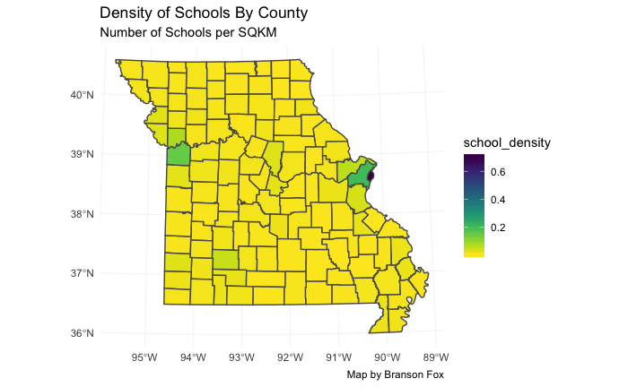

```r
ggplot() +
  geom_sf(data = schoolsByCounty, mapping = aes(fill = school_density)) +
  theme_minimal() +
  labs(
    title = "Density of Schools By County",
    subtitle = "Number of Schools per SQKM",
    caption = "Map by Branson Fox"
  ) +
  scale_fill_viridis(direction = -1) -> gg_density_km

gg_density_km
```

And to save it:

```r
ggsave(here("results", "schoolsDensityKM.png"), plot = gg_density_km, dpi = 500)
```

### Question 3

```r
ggplot() +
  geom_sf(data = schoolsByCounty, mapping = aes(fill = school_per_1k)) +
  theme_minimal() +
  labs(
    title = "Density of Schools By County",
    subtitle = "Number of Schools per 1000 People",
    caption = "Map by Branson Fox"
  ) +
  scale_fill_viridis(direction = -1) -> gg_density_1k

gg_density_1k
```

[output not shown]

And to save it:

```r
ggsave(here("results", "schoolsDensity1k.png"), plot = gg_density_1k, dpi = 500)
```